# Statistical Inference Lab Session

Lee Barnby

2024-10-03

# Lab Session 2: Statistical Inference

## Area under the Normal Distribution Curve

1. Approximately 95% of the area under the normal curve lies in the interval given by $\mu \pm 2\sigma$.
2. For $\mu = 0$ and $\sigma = 1$ (the standard normal distribution):
   - The upper interval limit is at the quantile 97.5.
   - The lower interval limit is at the quantile 2.5.
   - `qnorm(0.975)` gives 1.959964.
   - `qnorm(0.025)` gives -1.959964.
   - These values are approximately $\pm 2$. Insert a code block to verify this.

## Test for a Data Set Being Normally Distributed

We’ll use the `trees` dataset as an example:

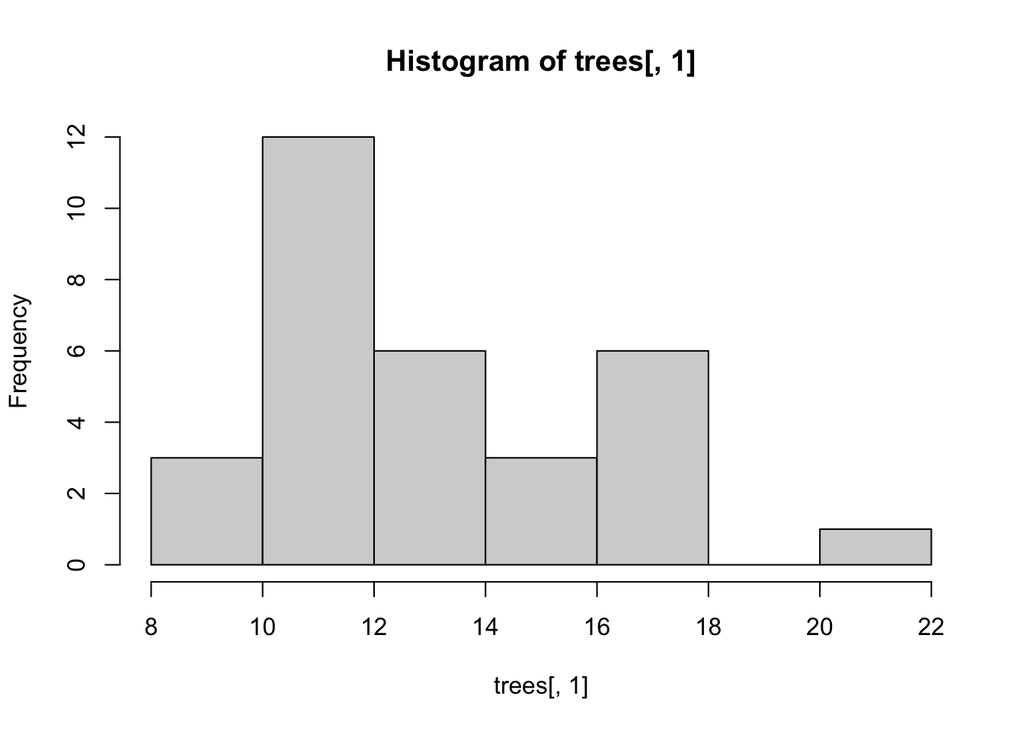

```r
# Load data
data(trees)

# Histograms
hist(trees[,1])
```

Repeat this for the second and third columns. You might want to use the help function to look up what these data represent.

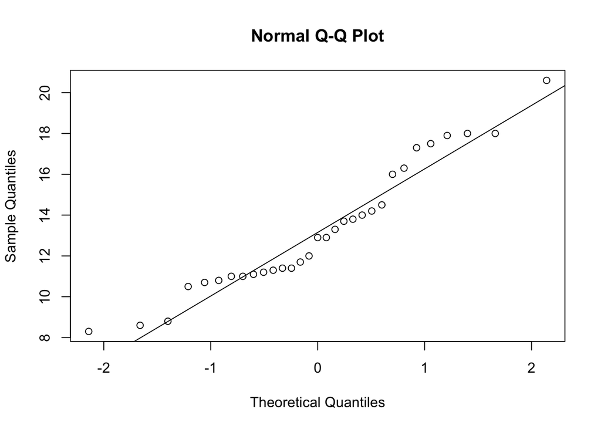

```r
# QQ plots
qqnorm(trees[,1])
qqline(trees[,1])
```

```r
# Shapiro-Wilk test
shapiro.test(trees[,1])
```

```
##
##  Shapiro-Wilk normality test
##
## data:  trees[, 1]
## W = 0.94117, p-value = 0.08893
```

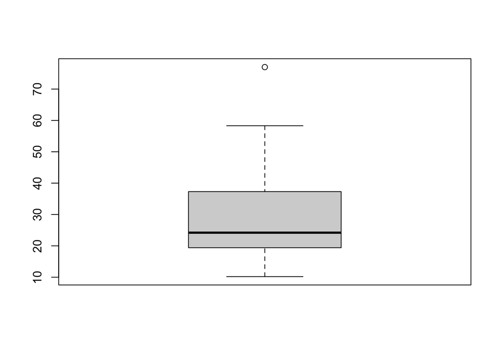

```r
# Box plot
boxplot(trees[,3])
```

## Example from Lecture

A random sample of 80 tablets had an average potency of 15mg with a known standard deviation of 4mg.

```r
# 95% confidence interval
qnorm(0.025, mean=15, sd=4/sqrt(80))
```

```
## [1] 14.12348
```

```r
qnorm(0.975, mean=15, sd=4/sqrt(80))
```

```
## [1] 15.87652
```

## Confidence Intervals

1. 95% confidence interval for the population mean $\mu$ is given by:
   $$\bar{x} \pm 1.96 \times \frac{\sigma}{\sqrt{n}}$$
2. Example: The weight of eggs sold by a grocery store is normally distributed with a standard deviation of 18 grams. A sample of 20 eggs has an average weight of 42 grams.

```r
# 95% confidence interval
mean_weight <- 42
sd_weight <- 18
n <- 20
error <- qnorm(0.975) * (sd_weight / sqrt(n))
ci_lower <- mean_weight - error
ci_upper <- mean_weight + error
ci_lower
```

```
## [1] 34.1113
```

```r
ci_upper
```

```
## [1] 49.8887
```

# Lab Session 3: Statistical Inference with Students t-Distribution

## Example from Lecture

26 measurements of the potency of a single batch of tablets:

```r
x <- c(498.38, 489.31, 505.5, 495.24, 490.17, 483.2, 488.47, 497.71, 503.41, 482.25, 488.14, 492.22, 483.96, 473.93, 463.4, 493.65, 499.48, 496.05, 494.54, 508.58, 488.42, 463.68, 492.46, 489.45, 491.57, 489.33)
mean(x)
```

```
## [1] 490.0962
```

```r
sd(x)
```

```
## [1] 10.78317
```

Can you use the ‘qt()’ command to find the 95% confidence interval for the mean potency of the batch?

## Confidence Intervals when the Data is Normally Distributed

1. 95% confidence interval for the sample mean when the variance is known:
   $$\bar{x} \pm 1.96 \times \frac{\sigma}{\sqrt{n}}$$
2. Example with known standard deviation:

```r
x2 <- c(238, 474, 359, 256, 481, 323, 151, 340, 284, 417, 424, 309, 139, 237, 269, 46, 350, 408, 223, 408, 286, 224, 238, 119, 343)
mean(x2) + qnorm(0.975) * (sd(x2)/sqrt(25))
```

```
## [1] 337.4194
```

```r
mean(x2) - qnorm(0.975) * (sd(x2)/sqrt(25))
```

```
## [1] 250.2606
```

What is wrong with this calculation?

## Determination of Sample Size for Estimating a Population Mean

```r
sd_eggs <- 8
z_alpha <- qnorm(0.99)
epsilon <- 2
n <- (z_alpha * sd_eggs / epsilon)^2
n
```

```
## [1] 86.59031
```

Documeent converted from pdf bu Co-pilot, edited and compiled by Lee Barnby on 2024-10-03.